# Semiparametric Generalized Linear Models with the gldrm Package

Michael J. Wurm

Department of Statistics, University of Wisconsin–Madison

Paul J. Rathouz

Department of Biostatistics & Medical Informatics, University of Wisconsin School of Medicine and Public Health

2018-05-21

Abstract

This paper introduces a new algorithm to estimate and perform inferences on a recently proposed and developed semiparametric generalized linear model (glm). Rather than selecting a particular parametric exponential family model, such as the Poisson distribution, this semiparametric glm assumes that the response is drawn from the more general exponential tilt family. The regression coefficients and unspecified reference distribution are estimated by maximizing a semiparametric likelihood. The new algorithm incorporates several computational stability and efficiency improvements over the algorithm originally proposed. In particular, the new algorithm performs well for either small or large support for the nonparametric response distribution. The algorithm is implemented in a new R package called *gldrm*.

# Introduction

(Rathouz and Gao 2009) introduced the generalized linear density ratio model (gldrm), which is a novel semiparametric formulation of the classical glm. Although Rathouz and Gao did not use the term gldrm, we refer to it as such because it is a natural extension of the density ratio model (see e.g. (Lovric 2011)). Like a standard glm, the gldrm relates the conditional mean of the response to a linear function of the predictors through a known link function $g$. To be specific, let the random variable $Y$ be a scalar response, and let $X$ be a $p \times 1$ covariate vector for a particular observation. The model for the mean is
$$\label{eqn:meanmodel}
\text{E}(Y|X=x) = g^{-1}(x^T \beta)\ . (\#eq:eqnmeanmodel)$$
Because Equation @ref(eq:eqnmeanmodel) holds for both gldrm and glm, the regression coefficients have the same interpretation for both models. The gldrm relaxes the standard glm assumption that the distribution of $Y|X$ comes from a particular exponential family model. Instead, assume that $Y|X$ comes from an exponential tilt model of the form
$$f(y|X=x) = f_0(y) \exp\{\theta
y - b(\theta)\}\ ,$$
where
$$b(\theta)
= \log \int f_0(y) \exp(\theta y)\ d\lambda(y)\ ,$$
and $\theta$ is defined implicitly as the solution to
$$\label{eqn:thetadef}
g^{-1}(x^T \beta) = \int y \exp\{\theta y - b(\theta)\}\ d\lambda(y)\
. (\#eq:eqnthetadef)$$
Here $f_0$ is an unspecified probability density with respect to a measure $\lambda$. We call $f_0$ the *reference distribution*. Measure $\lambda$ is Lebesgue if $Y|X$ is continuous, a counting measure if $Y|X$ is discrete, or a mixture of the two if $Y|X$ has a mixture distribution. Note that $\text{E}(Y|X) = b'(\theta)$ and $\text{Var}(Y|X) = b''(\theta)$, which are standard glm properties.

The regression coefficients $\beta$ and reference distribution $f_0$ are estimated by maximizing a semiparametric likelihood function, which contains a nonparametric representation of $f_0$ that has point mass only at values of $Y$ observed in the data. The quantity $\theta$ is not a parameter in this model, but rather a function of the free parameters $\beta$ and $f_0$, as well as of $X$. This work was fully developed by (Huang and Rathouz 2012), who first focused on the case where the covariate vector takes one of finitely many values, drawing on theoretical arguments advanced in the empirical likelihood literature (e.g. (Owen et al. 2001)). Drawing on semiparametric profile likelihood methods, (Huang 2014) went on to fully generalize the asymptotic arguments, proving consistency and asymptotic normality of the regression coefficient estimators, and deriving the asymptotic variance matrix using the profile likelihood. Huang also proved pointwise asymptotic normality of the reference cumulative distribution function estimator.

Despite these important theoretical advances, computation for this model has remained a practical challenge. The original algorithm in (Rathouz and Gao 2009) is somewhat rudimentary and applies mostly to cases with finite support. It does not scale well, and stability and speed are challenges. This paper proposes a new algorithm to address these challenges and render the model more widely applicable.

In particular, the issue of optimizing the semiparametric likelihood over the $f_0$ point masses is improved with application of the Broyden-Fletcher-Goldfarb-Shanno (BFGS) technique (Broyden 1970; Fletcher 1970; Goldfarb 1970; Shanno 1970). Because the number of parameters in the semiparametric likelihood associated with $f_0$ is equal to the number of unique points in the response vector, the rank of the Hessian matrix can become unwieldy, especially for continuous response data. The BFGS method uses an easily-computed rank-two approximate Hessian matrix that has an inverse which is much less computationally intensive to calculate.

The optimization techniques in this paper have been incorporated into the R package [*gldrm*](https://CRAN.R-project.org/package=gldrm) (Wurm and Rathouz 2018), the first CRAN package for gldrm. This package estimates the gldrm model and provides coefficient standard errors. In addition, since the publication of (Rathouz and Gao 2009), (Huang 2014) developed likelihood ratio tests and likelihood ratio-based confidence intervals for regression coefficients and demonstrated their strong properties. The *gldrm* package provides utilities for likelihood ratio tests of nested models, as well as confidence intervals.

We present our optimization algorithm in Section 2. In Section 3, we present simulation experiments to check the finite sample performance of the gldrm estimators and the accuracy of estimated standard errors using this algorithm. In Section 4, we discuss methods for inference. Section 5, we present a simulation that benchmarks the computational time and how it scales with the number of observations and number of covariates. In Section 6, we present a summary of the functions in the *gldrm* package. In Section 7, we demonstrate the functionality of the *gldrm* package with an example in R. In Section 8, we make concluding remarks.

# Optimization algorithm

Suppose we have an observed sample $(x_1, y_1), \ldots, (x_n, y_n)$ generated by the model specified in Equations @ref(eq:eqnmeanmodel)-@ref(eq:eqnthetadef). The $x_i$ can be fixed or random, and the $y_i$ are conditionally independent given the covariates. Let $\mathcal{S} = (s_1, \ldots, s_K)$ be the observed support, i.e. a vector containing the unique values in the set $\{y_1, \ldots, y_n\}$. If the response follows a continuous distribution, then $K$ will equal $n$. Otherwise $K$ may be less than $n$ due to ties. Let the vector $\tilde{f}_0 = (f_1, \ldots, f_K)$ represent probability mass at the points $(s_1, \ldots, s_K)$. This is a nonparametric representation of $f_0$ because the true reference density may be continuous or have probability mass at values not contained in $\mathcal{S}$.

The semiparametric log-likelihood is
$$\label{eqn:sp-loglik}
\ell(\beta, \tilde{f}_0) = \sum_{i=1}^n \left\{ \theta_i y_i - \log
\sum\limits_{k=1}^K f_k \exp(\theta_i s_k) + \sum\limits_{k=1}^K I(y_i =
s_k) \log f_k \right\} \ , (\#eq:eqnsp-loglik)$$
where each $\theta_i$ is defined implicitly as the solution to
$$\label{eqn:thetadef-sp}
g^{-1}(x_i^T \beta) = \frac{\sum\limits_{k=1}^K s_k f_k \exp\{\theta_i
s_k\}}{\sum\limits_{k=1}^K f_k \exp\{\theta_i s_k\}} \
. (\#eq:eqnthetadef-sp)$$
There exists a $\theta_i$ that satisfies Equation @ref(eq:eqnthetadef-sp) as long as $g^{-1}(x_i^T \beta) \in (m, M)$ for all $i$, where $m \equiv \min(\mathcal{S})$ and $M \equiv \max(\mathcal{S})$.

We obtain parameter estimates from this likelihood as $\underset{(\beta, \tilde{f}_0)}{\arg \max}\ \ell(\beta, \tilde{f}_0)$, subject to the following constraints:

C1. $g^{-1}(x_i^T \beta) \in (m, M)$ for all $i$

C2. $f_k > 0$ for all $k = 1, \ldots, K$

C3. $\sum\limits_{k=1}^K f_k = 1$

C4. $\sum\limits_{k=1}^K s_k f_k = \mu_0$ for some chosen $\mu_0 \in (m, M)$

Constraint (C4) is necessary for identifiability because for any nonparametric density $\tilde{f}_0 = (f_1, \ldots, f_k)^T$, the “exponentially tilted” density $\tilde{f}_0^{(\alpha)} = (f_1 e^{\alpha s_1}, \ldots, f_K e^{\alpha s_K})^T / \sum\limits_{k=1}^K f_k e^{\alpha s_k}$ has the same semiparametric log-likelihood for any $\alpha \in \mathbb{R}$, i.e. $\ell(\beta, \tilde{f}_0) = \ell(\beta, \tilde{f}_0^{(\alpha)})$ for all $\beta$. We can set $\mu_0$ to be any value within the range of observed response values, but choosing a value too extreme can lead to numerical instability in estimating $\tilde{f}_0$. It usually works well to choose $\mu_0 = \frac{1}{n} \sum\limits_{i=1}^n y_i$.

To perform the optimization, we take an iterative approach, alternating between optimizing over $\tilde{f}_0$ and over $\beta$ (Rathouz and Gao 2009). Each optimization step marginally optimizes the log-likelihood over one set of parameters, holding the other fixed. Neither optimization step has a closed form solution, so iterative procedures must be used. To update $\tilde{f}_0$, we propose using the BFGS technique. To update $\beta$, we use Fisher scoring, which is equivalent to iteratively re-weighted least squares (IRLS). We propose iterating BFGS until convergence for each $\tilde{f}_0$ update, while only using a single IRLS iteration to update $\beta$ in between $\tilde{f}_0$ updates; this is tantamount to a profile likelihood approach to estimation of $\beta.$

Although the log-likelihood in Equation @ref(eq:eqnsp-loglik) is a function of $(\beta, \tilde{f}_0)$, we have expressed it in terms of $(\theta_1, \ldots, \theta_n);$ each $\theta_i$ is implicitly a function of $(\beta, \tilde{f}_0)$. The score function is also best expressed in terms of the $\theta_i$’s (see Equations @ref(eq:eqnf0score) and @ref(eq:eqnbetascore)). Consequently, our optimization algorithm requires the $\theta_i$’s to be computed each time $\beta$ or $\tilde{f}_0$ is updated. To do this, we use an iterative Newton-Raphson procedure after each iteration of the $\beta$ update or the $\tilde{f}_0$ update procedures.

In what follows, we detail updates of the $\theta_i$’s, of $\tilde{f}_0$, and of $\beta$. We use the notation $b(\theta)$ to denote the function defined in Equation @ref(eq:eqnthetadef) with respect to the discrete probability distribution specified by $\tilde{f}_0$, i.e. $b(\theta) = \log \sum\limits_{k=1}^K f_k \exp(\theta s_k)$. We also define $\mu_i \equiv g^{-1}(x_i^T \beta)$.

## $\theta$ update procedure

$\theta_i$ is defined implicitly as the solution to Equation @ref(eq:eqnthetadef-sp), which can be written as
$$\label{eqn:theta-eqn}
\mu_i = b'(\theta_i) \ . (\#eq:eqntheta-eqn)$$
To calculate $\theta_i$, we use the Newton-Raphson procedure provided in Appendix C of (Rathouz and Gao 2009). To satisfy equation @ref(eq:eqntheta-eqn), we need to find $\theta$ such that $\mu_i = b'(\theta)$, or equivalently $g_l(\mu_i) = g_l\{b'(\theta)\}$, where $g_l(s) = \text{logit} \left( \frac{s - m}{M - m} \right) = \log \left( \frac{s - m}{M - s} \right)$. (The transformation, $g_l$, stabilizes the solution.)

We use Newton-Raphson to find the root of $t(\theta) = g_l\{b'(\theta)\} - g_l(\mu_i)$. Let $\theta^{(r)}$ denote the approximate solution at the $r^{\text{th}}$ Newton-Raphson iteration. The Newton-Raphson update is given by
$$\theta^{(r+1)} = \theta^{(r)} - \left\{
t'(\theta^{(r)}) \right\}^{-1} t(\theta^{(r)})\ ,$$
where
$$t'(\theta) = \frac{M -
m}{\{b'(\theta) - m\} \{M - b'(\theta)\}} b''(\theta)\
,$$
and
$$b''(\theta) =
\sum\limits_{k=1}^K \left\{s_k - b'(\theta) \right\}^2 f_k
\exp\left\{ \theta s_k - b(\theta) \right\}\ .$$

We typically initialize $\theta^{(0)}$ to be the value obtained from the previous $\theta$ update procedure. The first time $\theta$ is updated, we initialize $\theta^{(0)}$ to zero for every observation. We define convergence when $|t(\theta^{(r)})| < \epsilon$, where $\epsilon$ is a small threshold such as $10^{-10}$.

As $\mu_i \rightarrow M$ from the left, $\theta_i \rightarrow +\infty$. Likewise, as $\mu_i \rightarrow m$ from the right, $\theta_i \rightarrow -\infty$. To prevent numerical instability when $\mu_i$ is at or near these boundaries, we cap $|\theta_i|$ at a maximum value (500 by default). The appropriateness of this threshold would depend on the scale of response variable. Rather than adjust the threshold, we center and scale the response variable to the interval
$$-1, 1$$
(see the subsequent section on “response variable transformation”).

## $\tilde{f}_0$ optimization procedure

Holding $\beta$ fixed at its current estimate, we need to marginally optimize the log-likelihood $\ell(\beta, \tilde{f}_0)$ over $\tilde{f}_0$, subject to constraints (C2)-(C4). The linear constraints (C3) and (C4) could be enforced using constrained optimization techniques such as Lagrange multipliers or reducing the dimension of the parameter space by two. Huang and Rathouz (2012) used the former technique, while Rathouz and Gao (2009) used the latter. We propose a different method, based on the BFGS technique, that is more computationally efficient. At each iteration, we apply a BFGS update to $\tilde{f}_0$ to improve the unconstrained log-likelihood and then transform $\tilde{f}_0$ to satisfy constraints (C3) and (C4). Application of the constraints does not affect the log-likelihood of the estimate, as the constraints are only required for identifiability (i.e. uniqueness of the optimal $\tilde{f}_0$). For any set of positive $\tilde{f}_0$ values, there exists a unique set of values with equal log-likelihood that satisfies both constraints (C3) and (C4).

We define the transformation $\tilde{g}_0 = (g_1, \ldots, g_k) = (\log f_1, \ldots, \log f_K)$ and consider the log-likelihood as a function of $\tilde{g}_0$ only, with $\beta$ held fixed. Working on the log scale enforces constraint (C2) and also improves numerical stability. Specifically, numerical stability is improved by working with the score and Hessian as a function of $\tilde{g}_0$ rather than $\tilde{f}_0$.

BFGS is a quasi-Newton procedure, which makes iterative updates using an approximate Hessian matrix along with the exact score function. Let $\tilde{g}_0^{(t)}$ be the estimate at the $t^\text{th}$ iteration. The updates take the form
$$\label{eqn:bfgs-update}
\tilde{g}_0^{(t+1)} \leftarrow \tilde{g}_0^{(t)} - H_t^{-1}
S(\tilde{g}_0^{(t)}; \beta) \ . (\#eq:eqnbfgs-update)$$
Here, $S(\tilde{g}_0; \beta)$ is the score as a function of $\tilde{g}_0$ only, holding $\beta$ fixed. It has $k^\text{th}$ element
$$\label{eqn:f0score}
\{ S(\tilde{g}_0; \beta) \}_k = \sum\limits_{i=1}^n \left\{ I(y_i =
s_k) - \frac{\exp(g_k + \theta_i s_k)}{\exp\{b(\theta_i)\}} -
\frac{\exp(g_k + \theta_i s_k)}{\exp\{b(\theta_i)\}} \frac{s_k -
\mu_i}{b''(\theta_i)} (y_i - \mu_i)
\right\} (\#eq:eqnf0score)$$
for $k = 1, \ldots, K$ (derivation in Appendix A). Note that this score function ignores constraints (C3) and (C4). The matrix $H_t$ is an approximation to the Hessian of the log-likelihood as a function of $\tilde{g}_0$ only, holding $\beta$ fixed. This estimate is updated with each iteration. Letting $u_t = \tilde{g}_0^{(t)} - \tilde{g}_0^{(t-1)}$ and $v_t = S(\tilde{g}_0^{(t)}; \beta) - S(\tilde{g}_0^{(t-1)}; \beta)$, we can write the BFGS estimate of the Hessian recursively as
$$H_t = H_{t-1}
+ \frac{v_t v_t^T}{u_t^T v_t} - \frac{H_{t-1} u_t u_t^T H_{t-1}}{u_t^T
H_{t-1} u_t} \ .$$
$H_t$ is a rank-2 update to $H_{t-1}$ that satisfies the secant condition: $H_t u_t = v_t$. Furthermore, $H_t$ is guaranteed to be symmetric and positive definite, even though the true Hessian is not full rank. (The true Hessian is not full rank because without imposing constraints (C3) and (C4), the log-likelihood does not have a unique optimum.) The BFGS update in Equation @ref(eq:eqnbfgs-update) requires the inverse of $H_t$, which can be calculated efficiently and directly, without calculating $H_t$. By the Sherman-Morrison-Woodbury formula,
$$H_t^{-1} = H_{t-1}^{-1} +
\frac{(u_t^T v_t + v_t^T H_{t-1}^{-1} v_t)(u_t u_t^T)}{(u_t^T v_t)^2} -
\frac{H_{t-1}^{-1} v_t u_t^T + u_t v_t^T H_{t-1}^{-1}}{u_t^T v_t} \
.$$
For an initial estimate, we propose $H_0^{-1} = \alpha I_K$, where $I_K$ is the $K \times K$ identity matrix. We perform a line search along the gradient to choose an appropriate value for $\alpha$ such that $\ell(\beta, \tilde{f}_0^{(1)}) > \ell(\beta, \tilde{f}_0^{(0)})$.

As previously mentioned, constraints (C3) and (C4) are only required for identifiability. After each BFGS iteration, we impose these constraints on the $\tilde{f}_0$ estimate, which does not affect the log-likelihood of the estimate. Specifically, we apply (C3) by scaling our estimate of $\tilde{f}_0$ to sum to one. We then “exponentially tilt” the estimate to enforce constraint (C4). In other words, we compute $\theta$ such that $\sum\limits_{j=1}^K s_j f_j e^{\theta s_j} / \sum\limits_{j=1}^K f_j e^{\theta s_j} = \mu_0$, and set our final estimate for the iteration to be $f_k \leftarrow f_k e^{\theta s_k} / \sum\limits_{j=1}^K f_j e^{\theta s_j}$ for all $k$.

We initialize $\tilde{g}_0^{(0)}$ to the log of the $\tilde{f}_0$ estimate obtained from the previous $\tilde{f}_0$ update procedure. We suggest using the empirical response distribution as an initial estimate of $\tilde{f}_0$. We define convergence using the relative change in the log-likelihood. Our default convergence threshold is $10^{-10}$. If the log-likelihood decreases after any iteration, we backtrack by half steps, setting $\tilde{g}_0^{(t+1)} \leftarrow \frac{1}{2} \left( \tilde{g}_0^{(t+1)} + \tilde{g}_0^{(t)} \right)$ until the log-likelihood improves. In our experience, we have found that the log-likelihood improves after most iterations without taking half steps, but log-likelihood decreases can occur sporadically (both at early and late iterations).

## $\beta$ optimization procedure

Holding $\tilde{f}_0$ fixed at its current estimate, we could marginally optimize the log-likelihood over $\beta$ using iteratively re-weighted least squares (IRLS). Rather than iterating until convergence, however, we propose using a single IRLS iteration to update $\beta$ in between $\tilde{f}_0$ updates. The IRLS algorithm is simply the Newton-Raphson algorithm, but using the Fisher information in place of the negative Hessian matrix. This technique is commonly referred to as Fisher Scoring. As we now show, the Fisher Scoring update minimizes a weighted least squares expression, which is why we can refer to the algorithm as IRLS. The score function is given by
$$\label{eqn:betascore}
S(\beta; \tilde{f}_0)
= \sum\limits_{i=1}^n x_i \left( \frac{1}{g'(\mu_i)} \right) \left(
\frac{1}{b''(\theta_i)} \right) (y_i - \mu_i)
= \mathbf{X}^T \mathbf{W} \mathbf{r} \ , (\#eq:eqnbetascore)$$
(derivation in Appendix C) and the Fisher information is
$$\label{eqn:betainfo}
\begin{split}
\mathcal{I}(\beta; \tilde{f}_0) &= \text{E} \left( S(\beta;
\tilde{f}_0) S(\beta; \tilde{f}_0)^T \bigg| X_1=x_1, \ldots, X_n=x_n
\right) \\
&= \sum\limits_{i=1}^n x_i \left( \frac{1}{g'(\mu_i)} \right)^2
\left( \frac{1}{b''(\theta_i)} \right) x_i^T \\
&= \mathbf{X}^T \mathbf{W} \mathbf{X}\ ,
\end{split} (\#eq:eqnbetainfo)$$
where $\mathbf{X}$ is an $n \times p$ matrix with rows $x_i^T$, $\mathbf{W}$ is an $n \times n$ diagonal matrix with entries $\left( \frac{1}{g'(\mu_i)} \right)^2 \frac{1}{b''(\theta_i)}$, and $\mathbf{r}$ is an $n \times 1$ vector with entries $g'(\mu_i) (Y_i - \mu_i)$.

Let $\beta^{(0)}$ be the estimate obtained from the previous $\beta$ update procedure. The IRLS step between $\beta^{(0)}$ and the updated estimate, $\beta^{(1)}$, is
$$\label{eqn:beta-update}
\begin{split}
\beta^{(1)} - \beta^{(0)} &= \left\{ \mathcal{I}(\beta^{(0)};
\tilde{f}_0) \right\}^{-1} S(\beta^{(0)}; \tilde{f}_0) \\
&= \left( \mathbf{X}^T \mathbf{W} \mathbf{X} \right)^{-1}
\mathbf{X}^T \mathbf{W} \mathbf{r}\ .
\end{split} (\#eq:eqnbeta-update)$$
This is the solution to a weighted least squares expression, which can be computed efficiently using QR decomposition.

## Response variable transformation

Numerical stability issues can occur if the $\exp\{\theta_i s_k\}$ terms become too large or small during optimization. To prevent these terms from exceeding R’s default floating-point number range, we transform the response vector to the interval
$$-1,
1$$
. Specifically, the response values are transformed to $y_i^* = (y_i - \frac{m+M}{2}) \cdot \frac{2}{M-m}$. It turns out the semiparametric log-likelihood function with the transformed response and modified link function $g_*(\mu) = g(\frac{m+M}{2} + \frac{M-m}{2} \mu)$ is equivalent to the original log-likelihood. The parameters $\beta$ and $\tilde{f}_0$ that optimize the modified log-likelihood also optimize the original log-likelihood (proof in Appendix D).

As mentioned in the “$\theta$ update procedure” section, we choose to cap $|\theta|$ for each observation at 500 by default, thereby restricting the rescaled $\theta_i s_k$ terms to the interval
$$-500,
500$$
. Note that the optimization function in the *gldrm* R package returns the estimated $\theta_i$ values for each observation, and these values are on the original scale of the response variable.

# Inference

The *gldrm* R package (Wurm and Rathouz 2018) can perform inference on the regression coefficients using likelihood ratio tests for nested models. It can also calculate likelihood ratio, Wald, or score confidence intervals. All three confidence intervals should yield similar results for large samples, but the Wald form may be preferred for its computational simplicity. Likelihood ratio and score confidence intervals are more computationally expensive to calculate. Huang (2014) recommends likelihood ratio tests for small samples.

The Wald asymptotic variance estimate for the $\beta$ estimator can be obtained from the inverse of the information matrix given in Equation @ref(eq:eqnbetainfo). Recall this information matrix is calculated with the $\tilde{f}_0$ parameters held fixed. Its inverse is a valid asymptotic variance matrix because the full information matrix is block diagonal; i.e., the $\beta$ and $\tilde{f}_0$ estimators are asymptotically independent. The *gldrm* optimization function returns standard error estimates for each coefficient, which are displayed by the print method along with p-values. Wald confidence intervals are straightforward to calculate from the standard errors and can be obtained from the `gldrmCI` function. For these single-coefficient hypothesis tests and confidence intervals, we approximate the null distribution by a $t$-distribution with $n-p$ degrees of freedom, where $n$ is the number of observations and $p$ is the rank of the covariate matrix.

Likelihood ratio tests for nested models are based on the usual test statistic: 2 times the log-likelihood difference between the full and reduced model. Following Huang (2014), we approximate the null distribution by an $F$-distribution with $q$ and $n-p$ degrees of freedom, where $q$ is the difference in the number of parameters between the full and reduced models. This test can be performed by the `gldrmLRT` function.

Likelihood ratio and score confidence intervals for a single coefficient can be obtained from the `gldrmCI` function. These confidence intervals are more computationally expensive than Wald confidence intervals because an iterative method is required to search for the interval boundaries. We use the following bisection method.

Suppose we want to obtain the lower boundary of a confidence level $1-\alpha$ interval for a single coefficient $\beta^*$, and that the gldrm estimate of this coefficient is $\hat{\beta}^*$. For the lower boundary, we need to find $\beta_\text{lo}^*$ such that $\beta_\text{lo}^* < \hat{\beta}^*$ and the one-sided likelihood ratio test has a p-value equal to $\alpha / 2$ under the null hypothesis $H_0: \beta^* = \beta_\text{lo}^*$. As explained in the next paragraph, we can compute the p-value for any guess of $\beta_\text{lo}^*$. We begin by finding a guess that is too low (p-value less than $\alpha / 2$) and a guess that is too high (p-value greater than $\alpha / 2$). We then obtain the p-value of the midpoint. If the p-value is less than $\alpha / 2$ then the midpoint becomes the new low guess, and if it is greater than $\alpha / 2$ then the midpoint becomes the new high guess. We iterate this process, each time halving the distance between the low guess and high guess, until we have a guess of $\beta_\text{lo}^*$ that has a p-value arbitrarily close to $\alpha / 2$. The same procedure can be used to solve for $\beta_\text{hi}^*$.

Let $\beta_0$ be any constant. To calculate the likelihood ratio or score test p-value of $H_0: \beta^* = \beta_0$, we need to optimize the log-likelihood over $\tilde{f}_0$ and all other $\beta$ values, holding $\beta^*$ fixed at $\beta_0$. This can be done by multiplying $\beta_0$ with the column of the $\mathbf{X}$ matrix corresponding to $\beta^*$ and treating this vector as an offset to the linear predictor. In other words, this vector contains a fixed component of the linear predictor for each observation. The $\beta^*$ column is dropped from $\mathbf{X}$, and the model is optimized with the offset term.

# Goodness of fit

To check the model fit, we calculate the randomized probability inverse transform (Smith 1985). This is done by evaluating the fitted conditional cdf (i.e., the cumulative distribution function, conditional on the covariates) of each observed response value. If the model fit is good, the probability inverse transform values should roughly follow a uniform distribution on the interval (0, 1). Because the gldrm fitted cdf is discrete, we use randomization to make the distribution continuous as follows.

Let $\hat{F}(y|X=x)$ denote the fitted cdf conditional on a covariate vector $x$ evaluated at $y$, and let $y_i^- = \text{max} \left( \{y_j: y_j < y_i\} \bigcup \{-\infty\} \right)$. For each observation, we draw a random value from a uniform distribution on the interval $\left( \hat{F}(y_i | X = x_i),\ \hat{F}(y_i^- | X = x_i) \right)$.

To illustrate a good gldrm fit, we generate 1,000 independent pairs $(x, y)$ where $x \sim$ Normal(mean = 0, sd = 1) and $y|x \sim$ Normal(mean = x, sd = 1). The mean of $y|x$ is linear in $x$, and the data generating mechanism is an exponential tilt family, so we expect the gldrm fit to be good. We fit the model and then do a visual check by plotting the histogram and uniform QQ plot of the randomized probability inverse transform values (Figure 1).

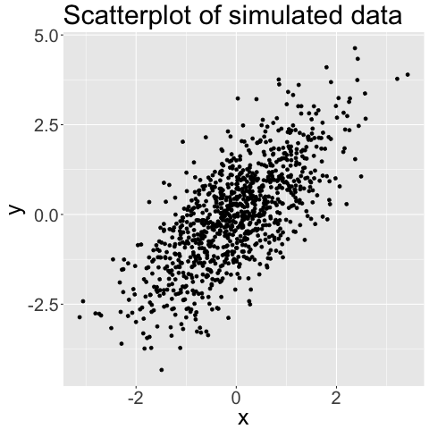

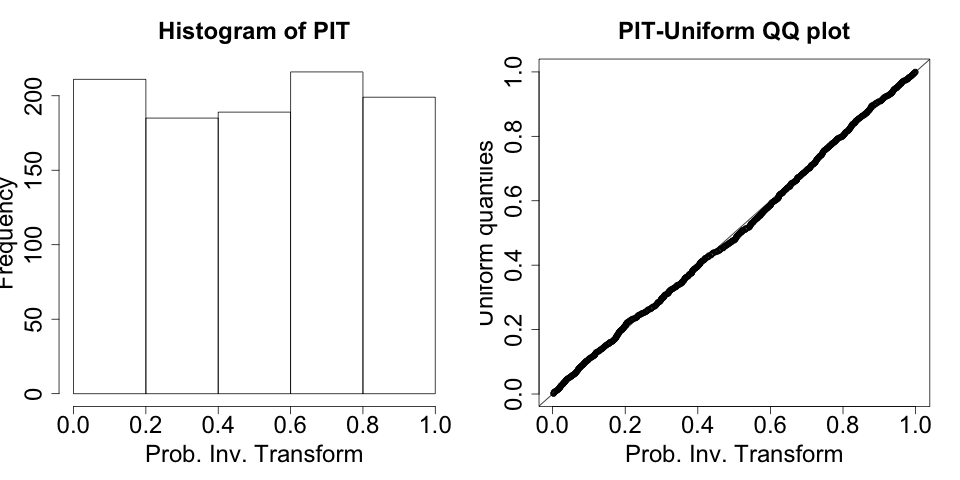

Figure 1: Scatterplot and probability inverse transform histogram and QQ plot for a good gldrm model fit.

To illustrate a poor gldrm fit, we generate 1,000 independent pairs $(x, y)$ where $x \sim$ Normal(mean = 0, sd = 1) and $y|x \sim$ Normal(mean = $x$, sd = $x^2$). The mean of $y|x$ is again linear in $x$, but this data generating mechanism is not an exponential tilt family. The diagnostic plots (Figure 2) confirm that the gldrm fit is not ideal. The probability inverse transform values are concentrated near the center of the interval (0, 1) rather than being uniformly distributed. The gldrm still provides a good estimate of the regression coefficients and the mean of $y|x$, but it is not the correct model for the cdf of $y|x$. .

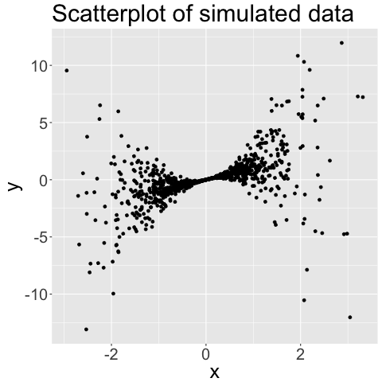

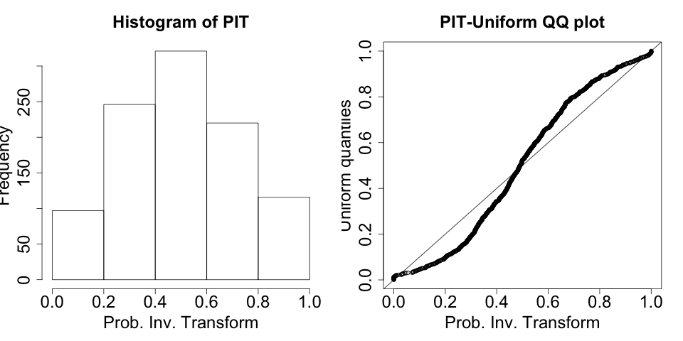

Figure 2: Scatterplot and probability inverse transform histogram and QQ plot for a poor gldrm model fit.

# Simulation experiments

Under four different simulation scenarios, we check the finite sample performance of the regression coefficient estimators, $\hat{\beta}$, as well as the reference distribution cdf estimator $\hat{F}_0()$. For $\hat{\beta}$, we also check the accuracy of the estimated standard errors.

For each simulation, the data generating mechanism is a gamma glm. The covariates are the same under each simulation setting, and their values are fixed, not random. The covariate vector is $x = (x_0, x_1, x_2, x_3)$. Variable $x_0$ is an intercept column of ones. Variable $x_1$ is an indicator with exactly 20% ones in each sample (observations 5, 10, 15, 20, $\ldots$ have $x_1=1$, and the rest have $x_1=0$). Variable $x_2$ is a continuous variable that follows a uniform sequence between zero and one in each sample (the first observation has $x_2=0$, and the last observation has $x_2=1$). Lastly, $x_3 = x_1 \cdot x_2$.

The coefficient values were $(\beta_1, \beta_2, \beta_3) = (1, 1, -2)$ for all simulation scenarios. The intercepts were $\beta_0 = 0$ for simulations 1 & 2, and $\beta_0 = 1$ for simulations 3 & 4. These values were selected so the mean response values were centered close to one and, for the identity link scenarios, guaranteed to be positive.

The log link was used for simulations 1 & 2, and the identity link was used for simulations 3 & 4. For all four simulations, the response was drawn from a gamma distribution with $\text{Var}(y|x) = \phi \text{E}(y|x)^2$, where $\phi$ varies by simulation to achieve different $R^2$ values. $R^2$ is defined as the squared correlation between the response and linear combination of predictors.

1. Simulation 1: log link and high $R^2$ ($\phi = 0.5$, $R^2 \approx 0.13$)
2. Simulation 2: log link and low $R^2$ ($\phi = 4$, $R^2 \approx 0.019$)
3. Simulation 3: identity link and high $R^2$ ($\phi = 0.25$, $R^2 \approx 0.13$)
4. Simulation 4: identity link and low $R^2$ ($\phi = 2$, $R^2 \approx 0.018$)

A gldrm was fit to each data set with correct link function and with $\tilde{f}_0$ constrained to have mean $\mu_0 = 1$. If we had followed our usual practice of choosing $\mu_0$ to be the sample mean of the observed response values, then the reference distribution would have a different mean for each simulation replicate. By choosing $\mu_0 = 1$ for all replicates, the true $f_0$ always follows a gamma distribution with mean one and variance $\phi$, where $\phi$ varies by simulation scenario. The value $\mu_0 = 1$ was chosen because, by design, it fell within the range of observed response values for all 2,000 replicates of each simulation scenario. The cumulative reference distribution estimate, denoted as $\hat{F}_0(\cdot)$, was computed at percentiles 0.1, 0.25, 0.5, 0.75, 0.9.

For each simulation scenario, we display four tables. The first table (Tables 1, 5, 9, and 13) contains the sample mean of each $\beta$ estimator. For comparison, we also calculated the gamma glm coefficient estimates for each simulated data set and display the sample mean alongside in parentheses.

The second table (Tables 2, 6, 10, and 14) contains the root mean squared error (rmse) of each $\beta$ estimator. The rmse is calculated as $\sqrt{\frac{1}{2000} \sum_{i=1}^{2000} (\hat{\beta}_i - \beta)^2}$, where $\hat{\beta}_i$ is the estimator of the $i^\text{th}$ simulation replicate, and $\beta$ is the true parameter value. For comparison, we also show the relative efficiency compared to the gamma glm estimator. Relative efficiency is calculated as $\text{mse}_{\text{glm}} / \text{mse}_{\text{gldrm}}$, where mse is the mean squared error (not rmse).

The third table (Tables 3, 7, 11, and 15) contains Wald confidence interval coverage rates for each $\beta$ estimator. Confidence intervals were calculated based on a $t$-distribution with $n - 4$ degrees of freedom.

The fourth table (Tables 4, 8, 12, and 16) contains the mean of $\hat{F}_0()$, calculated at the true $10^\text{th}$, $25^\text{th}$, $50^\text{th}$, $75^\text{th}$, and, $90^\text{th}$ percentiles.

To summarize the results, the gldrm estimators perform as expected. In all four simulation scenarios, the bias of $\hat{\beta}$ and $\hat{F}_0()$ goes to zero as the sample size increases. For the high $R^2$ scenarios, there is very little bias even at $n = 25$. Also, the relative efficiency of the $\beta$ estimators compared to the gamma glm estimators goes to one as the sample size increases. This is expected because, as Rathouz and Gao (2009) demonstrated, the $\beta$ and $f_0$ estimators are asymptotically orthogonal, so gldrm and glm have equal asymptotic efficiency when the glm model is correctly specified. For the high $R^2$ scenarios, the relative efficiency is close to one even at $n = 25$. For the low $R^2$ scenarios, the gldrm estimator is actually more efficient than the glm estimator for small sample sizes.

The standard error estimates for gldrm $\beta$ estimators are consistently low for small sample sizes, as demonstrated by low Wald confidence interval coverage rates. The coverage rates improve with increasing sample size, demonstrating good asymptotic properties of the standard error estimators. Likelihood ratio confidence intervals can be calculated with the *gldrm* R package and may have better small sample performance, as demonstrated by Huang (2014).

## Simulation 1

Simulation 1 uses log link with $\beta = (0, 1, 1, -2)$ and $\phi = 0.5$. This results in an $R^2$ of approximately 0.13. The simulation was replicated 2,000 times.

Table 1: Sample mean of $\hat{\beta}$. For comparison, the gamma glm sample mean is shown in parentheses.

|  | $\hat{\beta}$ mean (gamma glm mean) |  |  |
| --- | --- | --- | --- |
|  | n = 25 | n = 100 | n = 400 |
| $\beta_0 = 0$ | -0.02 (-0.02) | 0.00 (0.00) | 0.00 (0.00) |
| $\beta_1 = 1$ | 0.93 (0.92) | 0.98 (0.99) | 0.99 (0.99) |
| $\beta_2 = 1$ | 0.99 (1.00) | 0.99 (1.00) | 1.00 (1.00) |
| $\beta_3 = -2$ | -2.00 (-2.00) | -2.00 (-2.01) | -1.99 (-1.99) |

Table 2: Root mean squared error (rmse) of $\hat{\beta}$. In parentheses is the relative efficiency compared to the gamma glm estimator.

|  | $\hat{\beta}$ rmse (relative efficiency) |  |  |
| --- | --- | --- | --- |
|  | n = 25 | n = 100 | n = 400 |
| $\beta_0$ | 0.31 (0.99) | 0.16 (1.00) | 0.08 (1.00) |
| $\beta_1$ | 0.81 (0.96) | 0.38 (1.01) | 0.18 (1.00) |
| $\beta_2$ | 0.54 (1.00) | 0.27 (1.00) | 0.14 (0.99) |
| $\beta_3$ | 1.27 (0.96) | 0.63 (1.00) | 0.30 (1.00) |

Table 3: Wald confidence interval coverage rate for $\beta$.

|  | 80% C.I. |  |  | 90% C.I. |  |  | 95% C.I. |  |  |
| --- | --- | --- | --- | --- | --- | --- | --- | --- | --- |
|  | n = 25 | n = 100 | n = 400 | n = 25 | n = 100 | n = 400 | n = 25 | n = 100 | n = 400 |
| $\beta_0$ | 0.755 | 0.799 | 0.805 | 0.870 | 0.896 | 0.899 | 0.920 | 0.945 | 0.944 |
| $\beta_1$ | 0.677 | 0.764 | 0.800 | 0.782 | 0.860 | 0.900 | 0.837 | 0.919 | 0.949 |
| $\beta_2$ | 0.742 | 0.784 | 0.810 | 0.853 | 0.883 | 0.896 | 0.910 | 0.940 | 0.950 |
| $\beta_3$ | 0.681 | 0.767 | 0.806 | 0.800 | 0.869 | 0.907 | 0.867 | 0.920 | 0.948 |

Table 4: Sample mean of $\hat{F}_0$ at selected true percentiles.

|  |  | $\hat{F}_0(y)$ mean |  |  |
| --- | --- | --- | --- | --- |
| $F_0(y)$ | $y$ | n = 25 | n = 100 | n = 400 |
| 0.10 | 0.27 | 0.082 | 0.097 | 0.099 |
| 0.25 | 0.48 | 0.222 | 0.244 | 0.249 |
| 0.50 | 0.84 | 0.487 | 0.498 | 0.499 |
| 0.75 | 1.35 | 0.759 | 0.751 | 0.750 |
| 0.90 | 1.94 | 0.911 | 0.902 | 0.900 |

## Simulation 2

Simulation 2 uses log link with $\beta = (0, 1, 1, -2)$ and $\phi = 4$. This results in an $R^2$ of approximately 0.019. The simulation was replicated 2,000 times.

Table 5: Sample mean of $\hat{\beta}$. For comparison, the gamma glm sample mean is shown in parentheses.

|  | $\hat{\beta}$ mean (gamma glm mean) |  |  |
| --- | --- | --- | --- |
|  | n = 25 | n = 100 | n = 400 |
| $\beta_0 = 0$ | -0.16 (-0.19) | -0.05 (-0.06) | -0.02 (-0.02) |
| $\beta_1 = 1$ | 0.21 (0.29) | 0.80 (0.84) | 0.96 (0.97) |
| $\beta_2 = 1$ | 0.90 (0.96) | 0.99 (1.01) | 1.00 (1.00) |
| $\beta_3 = -2$ | -1.74 (-1.98) | -1.93 (-2.01) | -1.99 (-2.00) |

Table 6: Root mean squared error (rmse) of $\hat{\beta}$. In parentheses is the relative efficiency compared to the gamma glm estimator.

|  | $\hat{\beta}$ rmse (relative efficiency) |  |  |
| --- | --- | --- | --- |
|  | n = 25 | n = 100 | n = 400 |
| $\beta_0$ | 0.94 (1.14) | 0.45 (1.04) | 0.23 (1.00) |
| $\beta_1$ | 2.83 (1.43) | 1.12 (1.09) | 0.51 (1.02) |
| $\beta_2$ | 1.62 (1.19) | 0.78 (1.05) | 0.39 (1.01) |
| $\beta_3$ | 4.18 (1.59) | 1.88 (1.14) | 0.89 (1.02) |

Table 7: Wald confidence interval coverage rate for $\beta$.

|  | 80% C.I. |  |  | 90% C.I. |  |  | 95% C.I. |  |  |
| --- | --- | --- | --- | --- | --- | --- | --- | --- | --- |
|  | n = 25 | n = 100 | n = 400 | n = 25 | n = 100 | n = 400 | n = 25 | n = 100 | n = 400 |
| $\beta_0$ | 0.704 | 0.770 | 0.782 | 0.806 | 0.877 | 0.888 | 0.869 | 0.933 | 0.945 |
| $\beta_1$ | 0.626 | 0.724 | 0.781 | 0.732 | 0.832 | 0.883 | 0.794 | 0.897 | 0.935 |
| $\beta_2$ | 0.680 | 0.755 | 0.774 | 0.795 | 0.862 | 0.881 | 0.869 | 0.925 | 0.939 |
| $\beta_3$ | 0.633 | 0.722 | 0.762 | 0.750 | 0.829 | 0.879 | 0.819 | 0.895 | 0.935 |

Table 8: Sample mean of $\hat{F}_0$ at selected true percentiles.

|  |  | $\hat{F}_0(y)$ mean |  |  |
| --- | --- | --- | --- | --- |
| $F_0(y)$ | $y$ | n = 25 | n = 100 | n = 400 |
| 0.10 | 0.00 | 0.093 | 0.100 | 0.101 |
| 0.25 | 0.01 | 0.230 | 0.247 | 0.250 |
| 0.50 | 0.17 | 0.465 | 0.496 | 0.499 |
| 0.75 | 1.04 | 0.727 | 0.747 | 0.749 |
| 0.90 | 3.00 | 0.903 | 0.899 | 0.900 |

## Simulation 3

Simulation 3 uses identity link with $\beta = (1, 1, 1, -2)$ and $\phi = 0.25$. This results in an $R^2$ of approximately 0.13. The simulation was replicated 2,000 times.

Table 9: Sample mean of $\hat{\beta}$. For comparison, the gamma glm sample mean is shown in parentheses.

|  | $\hat{\beta}$ mean (gamma glm mean) |  |  |
| --- | --- | --- | --- |
|  | n = 25 | n = 100 | n = 400 |
| $\beta_0 = 1$ | 1.00 (1.00) | 0.99 (0.99) | 1.00 (1.00) |
| $\beta_1 = 1$ | 1.01 (1.01) | 1.00 (1.00) | 0.99 (0.99) |
| $\beta_2 = 1$ | 1.01 (1.01) | 1.01 (1.01) | 1.00 (1.00) |
| $\beta_3 = -2$ | -2.02 (-2.01) | -2.01 (-2.01) | -1.99 (-1.99) |

Table 10: Root mean squared error (rmse) of $\hat{\beta}$. In parentheses is the relative efficiency compared to the gamma glm estimator.

|  | $\hat{\beta}$ rmse (relative efficiency) |  |  |
| --- | --- | --- | --- |
|  | n = 25 | n = 100 | n = 400 |
| $\beta_0$ | 0.25 (0.99) | 0.13 (0.99) | 0.07 (1.00) |
| $\beta_1$ | 0.88 (0.96) | 0.40 (0.99) | 0.20 (1.00) |
| $\beta_2$ | 0.55 (0.98) | 0.28 (0.99) | 0.14 (1.00) |
| $\beta_3$ | 1.26 (0.98) | 0.63 (0.98) | 0.32 (1.00) |

Table 11: Wald confidence interval coverage rate for $\beta$.

|  | 80% C.I. |  |  | 90% C.I. |  |  | 95% C.I. |  |  |
| --- | --- | --- | --- | --- | --- | --- | --- | --- | --- |
|  | n = 25 | n = 100 | n = 400 | n = 25 | n = 100 | n = 400 | n = 25 | n = 100 | n = 400 |
| $\beta_0$ | 0.735 | 0.793 | 0.802 | 0.830 | 0.888 | 0.892 | 0.888 | 0.939 | 0.947 |
| $\beta_1$ | 0.670 | 0.789 | 0.799 | 0.785 | 0.875 | 0.892 | 0.847 | 0.931 | 0.949 |
| $\beta_2$ | 0.737 | 0.782 | 0.796 | 0.849 | 0.885 | 0.893 | 0.916 | 0.941 | 0.943 |
| $\beta_3$ | 0.667 | 0.773 | 0.792 | 0.800 | 0.876 | 0.896 | 0.872 | 0.937 | 0.942 |

Table 12: Sample mean of $\hat{F}_0$ at selected true percentiles.

|  |  | $\hat{F}_0(y)$ mean |  |  |
| --- | --- | --- | --- | --- |
| $F_0(y)$ | $y$ | n = 25 | n = 100 | n = 400 |
| 0.10 | 0.44 | 0.077 | 0.095 | 0.098 |
| 0.25 | 0.63 | 0.219 | 0.244 | 0.249 |
| 0.50 | 0.92 | 0.492 | 0.498 | 0.499 |
| 0.75 | 1.28 | 0.769 | 0.753 | 0.751 |
| 0.90 | 1.67 | 0.913 | 0.903 | 0.901 |

## Simulation 4

Simulation 4 uses identity link with $\beta = (1, 1, 1, -2)$ and $\phi = 2$. This results in an $R^2$ of approximately 0.018. The simulation was replicated 2,000 times.

Table 13: Sample mean of $\hat{\beta}$. For comparison, the gamma glm sample mean is shown in parentheses.

|  | $\hat{\beta}$ mean (gamma glm mean) |  |  |
| --- | --- | --- | --- |
|  | n = 25 | n = 100 | n = 400 |
| $\beta_0 = 1$ | 1.02 (1.02) | 1.01 (1.01) | 1.00 (1.00) |
| $\beta_1 = 1$ | 0.91 (0.89) | 0.97 (1.00) | 0.99 (0.99) |
| $\beta_2 = 1$ | 0.99 (1.02) | 0.97 (0.98) | 0.99 (1.00) |
| $\beta_3 = -2$ | -1.86 (-1.85) | -1.92 (-1.95) | -1.98 (-1.99) |

Table 14: Root mean squared error (rmse) of $\hat{\beta}$. In parentheses is the relative efficiency compared to the gamma glm estimator.

|  | $\hat{\beta}$ rmse (relative efficiency) |  |  |
| --- | --- | --- | --- |
|  | n = 25 | n = 100 | n = 400 |
| $\beta_0$ | 0.73 (1.17) | 0.39 (1.02) | 0.19 (1.00) |
| $\beta_1$ | 2.35 (1.05) | 1.16 (1.09) | 0.58 (1.02) |
| $\beta_2$ | 1.58 (1.18) | 0.81 (1.03) | 0.40 (1.00) |
| $\beta_3$ | 3.27 (1.18) | 1.83 (1.11) | 0.92 (1.02) |

Table 15: Wald confidence interval coverage rate for $\beta$.

|  | 80% C.I. |  |  | 90% C.I. |  |  | 95% C.I. |  |  |
| --- | --- | --- | --- | --- | --- | --- | --- | --- | --- |
|  | n = 25 | n = 100 | n = 400 | n = 25 | n = 100 | n = 400 | n = 25 | n = 100 | n = 400 |
| $\beta_0$ | 0.661 | 0.761 | 0.794 | 0.754 | 0.845 | 0.893 | 0.802 | 0.893 | 0.938 |
| $\beta_1$ | 0.595 | 0.718 | 0.767 | 0.692 | 0.822 | 0.868 | 0.741 | 0.870 | 0.921 |
| $\beta_2$ | 0.665 | 0.769 | 0.779 | 0.777 | 0.864 | 0.895 | 0.847 | 0.910 | 0.943 |
| $\beta_3$ | 0.666 | 0.711 | 0.777 | 0.789 | 0.824 | 0.877 | 0.871 | 0.892 | 0.932 |

Table 16: Sample mean of $\hat{F}_0$ at selected true percentiles.

|  |  | $\hat{F}_0(y)$ mean |  |  |
| --- | --- | --- | --- | --- |
| $F_0(y)$ | $y$ | n = 25 | n = 100 | n = 400 |
| 0.10 | 0.02 | 0.085 | 0.097 | 0.100 |
| 0.25 | 0.10 | 0.223 | 0.246 | 0.249 |
| 0.50 | 0.45 | 0.474 | 0.493 | 0.499 |
| 0.75 | 1.32 | 0.741 | 0.749 | 0.750 |
| 0.90 | 2.71 | 0.907 | 0.902 | 0.900 |

## Likelihood ratio and score confidence intervals

To support our claim that likelihood ratio confidence intervals may have better small sample performance, we compared the Wald, likelihood ratio, and score 95% confidence interval coverage rates under the settings of Simulation 1 with $n = 25$. The coverage rates are shown in Table 17. The Wald coverage rates are similar to those in Table 3, but not identical because this experiment used a new set of 2,000 replicates.

Table 17: Coverage rates for 95% confidence intervals under the settings of Simulation 1.

|  | $\beta_0$ | $\beta_1$ | $\beta_2$ | $\beta_3$ |
| --- | --- | --- | --- | --- |
| Wald | 0.918 | 0.823 | 0.909 | 0.859 |
| Likelihood ratio | 0.969 | 0.939 | 0.958 | 0.944 |
| Score | 0.976 | 0.966 | 0.967 | 0.967 |

# Computational time and scaling

The following simulation explores the computation time of *gldrm* and how it scales with the number of observations $n$ and number of covariates $p$. For each value of $n$ and $p$, we fit *gldrm* to 100 randomly generated data sets. A gldrm was fit once to each data set.

Covariates were drawn independently from a standard normal distribution, and coefficients were drawn independently from a uniform distribution on the interval (-1, 1). Simulation 1 used an identity link function with response drawn from a normal distribution with variance function $V(\mu) = 1$. Simulation 2 used a log link function with response drawn from an exponential distribution, i.e. a gamma distribution with variance function $V(\mu) = \mu^2$.

Iteration limits were set at 100 per $\theta$ update, 1,000 per $f_0$ update, and 100 for the outer loop (for which each iteration consists of a single-iteration $\beta$ update, followed by an $f_0$ update). Convergence thresholds were set at $10^{-10}$ for the $\theta$ update, $f_0$ update, and outer loop update. This experiment was run using a 2.2 GHz AMD Opteron 6174 processor. Figures 3 and 4 show the average CPU seconds for Simulations 1 and 2, respectively.

We also repeated this experiment with the number of support points fixed at 25. To do this, we generated $n$ response values from the model. The first 25 values were designated as the support, and the remaining response values were matched to the nearest support value and set to that value. This discrete data generating model is not actually a gldrm model, but we are only using it to evaluate computation time. Figures 5 and 6 show the average CPU seconds for Simulations 1 and 2, respectively, with support size fixed at 25.

In summary, the computation time scales roughly linearly with $n$ when the support is fixed at 25. When the support grows with $n$, the computation time grows faster than linearly. Computation time increases with $p$, but there is not a consistent pattern, especially with fixed support.

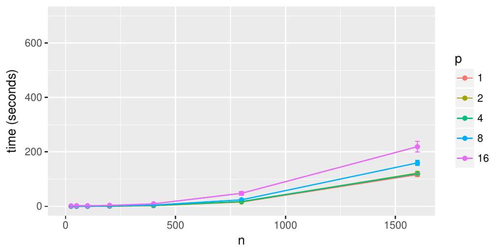

Figure 3: Mean computation time for Simulation 1. Error bars represent $\pm 2$ standard errors over 100 replicates.

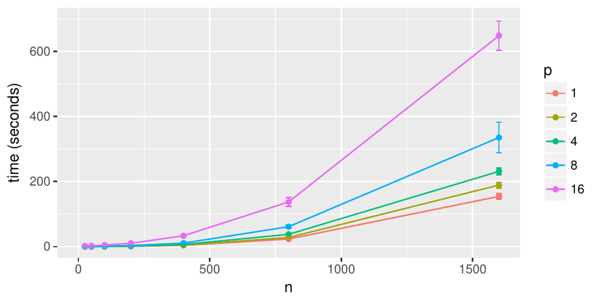

Figure 4: Mean computation time for Simulation 2. Error bars represent $\pm 2$ standard errors over 100 replicates.

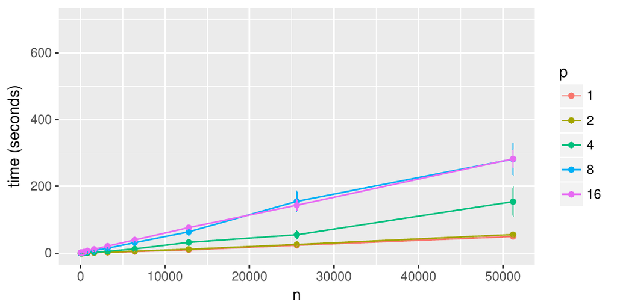

Figure 5: Mean computation time for Simulation 1 with support size fixed at 25. Error bars represent $\pm 2$ standard errors over 100 replicates.

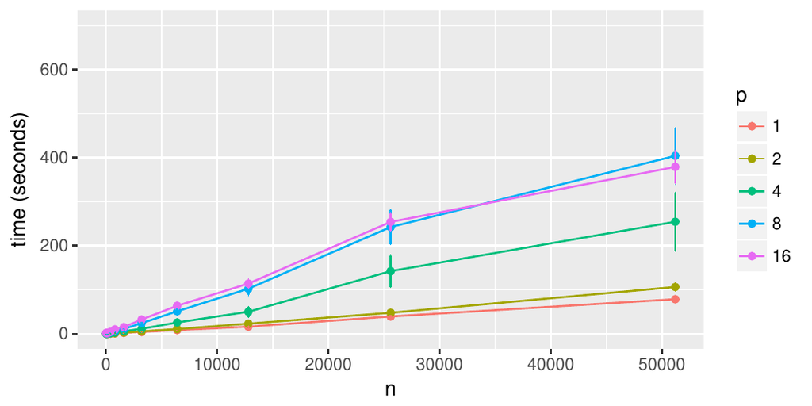

Figure 6: Mean computation time for Simulation 2 with support size fixed at 25. Error bars represent $\pm 2$ standard errors over 100 replicates.

# R package: gldrm

# R example: iris data

We demonstrate the *gldrm* package using the Iris data set from the *datasets* package. This is a data set of $n = 150$ observations. We choose sepal length to be the response variable. This variable has 35 unique values, so the support is $K = 35$. We first demonstrate how to fit a gldrm model with the optimization function, which is simply called `gldrm`. We demonstrate how to perform inference on the regression coefficients. We check the goodness of fit using the randomized probability inverse transform. Finally we show how to obtain predictions for a set of observations, including the predicted mean and nonparametric estimate of the distribution function.

## Fit gldrm model

The `gldrm` optimization function takes a formula and data argument, similar to R’s `glm` function. Instead of passing both an error distribution and link function through a family argument, the `gldrm` only requires a link function. The `link` argument will accept the name of a link function (any function supported by `make.link` in the `stats` package is accepted). Alternatively, a custom link function can be passed as a list containing three items:

1. `linkfun` A vectorized link function.
2. `linkinv` The corresponding inverse link function, also vectorized.
3. `mu.eta` The derivative of the inverse link function, also vectorized.

This list structure is the same as that of `link-glm` class objects, which are constructed by the `make.link` function. The custom link option allows great flexibility, but it is imperative that the user correctly specifies the inverse link and its derivative.

```r
R> ### Load gldrm package and Iris data from datasets package
R> library(gldrm)
R> data(iris, package = "datasets")

R> ### Fit gldrm with all variables
R> fit <- gldrm(Sepal.Length ~ Sepal.Width + Petal.Length + Petal.Width + Species,
R+              data = iris, link = "log")
R> fit

Summary of gldrm fit

Coefficients:
Estimate Std. Error t value Pr(>|t|)
(Intercept)         1.1832     0.0369   32.10  < 2e-16 ***
Sepal.Width         0.0788     0.0128    6.17  6.4e-09 ***
Petal.Length        0.1128     0.0102   11.04  < 2e-16 ***
Petal.Width        -0.0350     0.0248   -1.41    0.162
Speciesversicolor  -0.0561     0.0395   -1.42    0.157
Speciesvirginica   -0.0994     0.0557   -1.79    0.076 .
---
Signif. codes:  0 ‘***’ 0.001 ‘**’ 0.01 ‘*’ 0.05 ‘.’ 0.1 ‘ ’ 1

Likelihood ratio test against null model:
F-statistic:  57.4
Numerator degrees of freedom:  5
Denominator degrees of freedom:  144
P-value:  < 2e-16
```

## Inference

The `gldrmLRT` function performs a semiparametric likelihood ratio test between two nested models. We demonstrate this on the Iris data by fitting a sub-model that excludes "Species", which is a categorical variable with three levels and two degrees of freedom. We also obtain Wald and likelihood ratio confidence intervals for the petal width coefficient.

```r
R> ### Fit gldrm without the categorical variable "Species"
R> fit0 <- gldrm(Sepal.Length ~ Sepal.Width + Petal.Length + Petal.Width,
R+               data = iris, link = "log")

R> ### Likelihood ratio test for the nested models
R> gldrmLRT(fit, fit0)

Likelihood ratio test:

F-statistic:  2.03
Numerator degrees of freedom:  2
Denomicator degrees of freedom:  144
P-value:  0.135

R> ### Wald 95% confidence interval for Petal.Width
R> gldrmCI(fit, term = "Petal.Width", test = "Wald", type = "2-sided", level = .95)

95% Wald confidence interval for Petal.Width:
(-0.084, 0.014)

R> ### Likelihood ratio 95% confidence interval for Petal.Width
R> gldrmCI(fit, term = "Petal.Width", test = "LRT", type = "2-sided", level = .95)

95% likelihood ratio confidence interval for Petal.Width:
(-0.094, 0.025)
```

## Goodness of fit

The `gldrmPIT` function produces goodness of fit plots using the probability inverse transform. In addition to plotting, this function also returns the inverse transform values as a vector.

```r
R> pit <- gldrmPIT(fit)
```

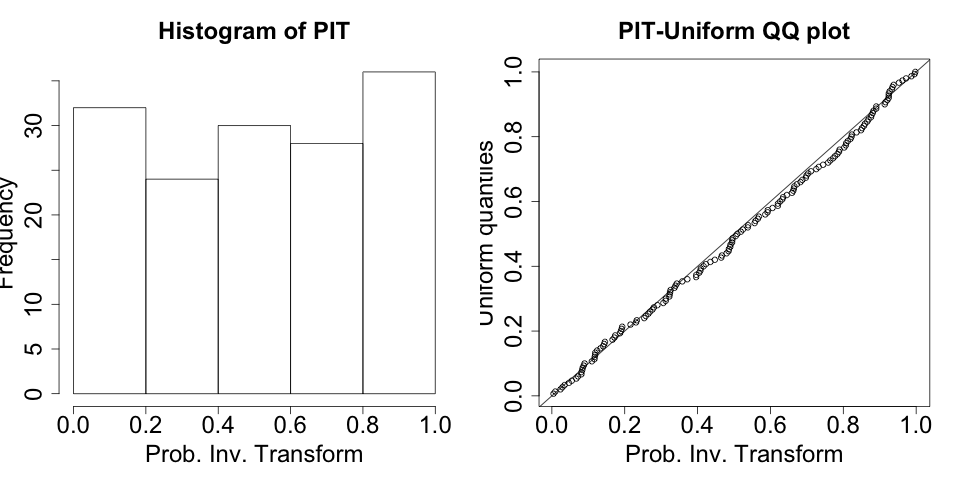

## Prediction

We obtain predictions for three selected observations in the data set: one from each Species. These observations were contained in training data, but we could obtain predictions for out-of-sample observations in the same way. Using the `predict` method, we obtain the fitted mean response value for each observation, which is the estimate of $\text{E}(Y | X = x)$.

We also use the `predict` method to obtain the nonparametric estimate of the conditional density $f(y | X=x)$. This is obtained by setting the argument `type = "fTilt"`, which returns an $n \times K$ matrix with $(i, k)^\text{th}$ entry $\tilde{f}_k \exp\{\theta_i s_k - b(\theta_i)\}$. Each row contains the nonparametric conditional density estimate for a given observation and sums to one. We use this matrix to calculate the conditional probabilities for the form $\text{P}(y_1 < Y \le y_2 | X=x)$ for each observation. Note that all observed support values (sepal length values) fall between four and eight, so all probability mass falls within this interval.

```r
R> ### Select three observations; one from each Species
R> newdata <- iris[c(1, 51, 101), ]

R> ### Fitted mean Sepal.Length
R> fitted_mean <- predict(fit, newdata = newdata, type = "response")
R> fitted_mean <- round(fitted_mean, 2)

R> ### Estimated Sepal.Length distribution of each observation
R> ### Note: all Sepal.Length values are between 4 and 8
R> fTilt <- predict(fit, newdata = newdata, type = "fTilt")
R> spt <- fit$spt
R> F4 <- rowSums(fTilt[ , spt <= 4])
R> F5 <- rowSums(fTilt[ , spt <= 5])
R> F6 <- rowSums(fTilt[ , spt <= 6])
R> F7 <- rowSums(fTilt[ , spt <= 7])
R> F8 <- rowSums(fTilt[ , spt <= 8])
R> Ftilt <- cbind(F5-F4, F6-F5, F7-F6, F8-F7)
R> Ftilt <- round(Ftilt, 3)
R> colnames(Ftilt) <- c("P(4=Y<=5)", "P(5<Y<=6)", "P(6<Y<=7)", "P(7<Y<=8)")
R> cbind(newdata, fitted_mean, Ftilt)
```

```r
    Sepal.Length Sepal.Width Petal.Length Petal.Width    Species fitted_mean
1            5.1         3.5          1.4         0.2     setosa        5.00
51           7.0         3.2          4.7         1.4 versicolor        6.43
101          6.3         3.3          6.0         2.5  virginica        6.91
    P(4<Y<=5) P(5<Y<=6) P(6<Y<=7) P(7<Y<=8)
1       0.625     0.375     0.000     0.000
51      0.000     0.136     0.832     0.032
101     0.000     0.006     0.649     0.344
```

# Discussion

We introduced a new optimization algorithm for gldrm, which computationally scales better with the number of unique observed response values. This is especially useful for estimation of continuous response data where the number of parameters in the $\tilde{f}_0$ parameter equals the sample size. In particular, the BFGS technique dramatically speeds up the $\tilde{f}_0$ optimization step, and makes gldrm much more computationally feasible for either discrete or continuous response data. The new algorithm is implemented in the *gldrm* package. Simulation results show that the algorithm and software obtain accurate estimates and standard errors. Computational time was shown to be feasible for support sizes well over one thousand.

Future research directions could include the incorporation of random effects into the gldrm framework. Optimization techniques for generalized linear mixed models, such as adaptive Gaussian quadrature, may be useful for model estimation (Pinheiro and Chao 2006; Pinheiro and Bates 1995).

# Acknowledgments

Research reported in this publication was supported by the National Heart, Lung, and Blood Institute of the National Institutes of Health under award number T32 HL083806 (for MJW) and R01 HL094786-05A1 (for PJR). The content is solely the responsibility of the authors and does not necessarily represent the official views of the National Institutes of Health.

We thank Dr. Alan Huang, University of Queensland, for suggesting the use of probability inverse transform diagnostic plots, as well as providing the corresponding code, which we have incorporated into the *gldrm* package.

# Notation

In this appendix, we use $\partial$ to denote the partial derivative and $d$ to denote the total derivative. We require this notation for chain rule derivatives, specifically to derive the score function with respect to $\beta$ and $\tilde{f}_0$. Each $\theta_i$ is implicitly a function of $(\beta, \tilde{f}_0)$ and hence should not be held fixed when differentiating the log-likelihood with respect to either $\beta$ or $\tilde{f}_0$. We also let
$$\label{eqn:elli-def}
\ell_i = \theta_i y_i - \log \sum\limits_{k=1}^K f_k \exp(\theta_i s_k)
+ \sum\limits_{k=1}^K I(y_i = s_k) \log
f_k (\#eq:eqnelli-def)$$
denote the contribution of the $i^\text{th}$ observation to the log-likelihood.

# A. Score function for $\tilde{f}_0$

We derive Equation @ref(eq:eqnf0score), which gives the score function with respect to $\tilde{f}_0$, holding $\beta$ fixed. Using the definition of $\ell_i$ in Equation @ref(eq:eqnelli-def) and applying the chain rule, the $k^\text{th}$ element of the score function is
$$\label{eqn:f0score-chain}
\{ S(\tilde{f}_0; \beta) \}_k = \frac{d \ell(\beta, \tilde{f}_0)}{d f_k}
= \sum\limits_{i=1}^n \frac{d \ell_i}{d f_k}
= \sum\limits_{i=1}^n \left( \frac{\partial \ell_i}{\partial f_k} +
\frac{d \theta_i}{d f_k} \frac{\partial \ell_i}{\partial \theta_i}
\right) \ . (\#eq:eqnf0score-chain)$$
The first term on the RHS of Equation @ref(eq:eqnf0score-chain) is
$$\label{eqn:f0score-term1}
\frac{\partial \ell_i}{\partial f_k} = \frac{I(y_i = s_k)}{f_k} -
\frac{\exp\{\theta_i s_k\}}{\sum\limits_{m=1}^K f_m \exp\{\theta_i
s_m\}} \ . (\#eq:eqnf0score-term1)$$
The second term on the RHS of Equation @ref(eq:eqnf0score-chain) is
$$\label{eqn:f0score-term2}
\frac{\partial \ell_i}{\partial \theta_i}
= y_i - \frac{\sum\limits_{k=1}^K s_k f_k \exp\{\theta
s_k\}}{\sum\limits_{k=1}^K f_k \exp\{\theta s_k\}}
= y_i - \mu_i \ . (\#eq:eqnf0score-term2)$$
Recall that $\mu_i = g^{-1}(x_i^T \beta)$, which does not vary with $\tilde{f}_0$. Therefore,
$$0 = \frac{d}{d f_k} \mu_i
= \frac{\partial \mu_i}{\partial f_k} + \frac{d \theta_i}{d f_k}
\frac{\partial \mu_i}{\partial \theta_i} \ ,$$
and the third term on the RHS of Equation @ref(eq:eqnf0score-chain) is
$$\label{eqn:f0score-term3}
\frac{d \theta_i}{d f_k}
= -\frac{\partial \mu_i}{\partial f_k} \bigg/ \frac{\partial
\mu_i}{\partial \theta_i}
= -\frac{\exp\{\theta_i s_k\} (s_k - \mu_i)}{\exp\{b(\theta_i)\}} \bigg/
b''(\theta_i) \ . (\#eq:eqnf0score-term3)$$
Plugging the results of Equations @ref(eq:eqnf0score-term1), @ref(eq:eqnf0score-term2), and @ref(eq:eqnf0score-term3) into Equation @ref(eq:eqnf0score-chain), we obtain
$$\{
S(\tilde{f}_0; \beta) \}_k = \sum\limits_{i=1}^n \left\{ \frac{I(y_i =
s_k)}{f_k} - \frac{\exp(\theta_i s_k)}{\exp\{b(\theta_i)\}} -
\frac{\exp(\theta_i s_k)}{\exp\{b(\theta_i)\}} \frac{s_k -
\mu_i}{b''(\theta_i)} (y_i - \mu_i) \right\} \ .$$
We obtain the result of Equation @ref(eq:eqnf0score) by applying the Jacobian transformation $\{S(\tilde{g}_0; \beta)\}_k = f_k \{S(\tilde{f}_0; \beta)\}_k$.

# B. Information matrix for $\tilde{f}_0$

The $\tilde{f}_0$ information matrix is not used during the BFGS optimization routine. However, we derive it here to correct a missing term in the Rathouz and Gao (2009) derivation. Each matrix element is

$$\label{eqn:f0info1}
\begin{split}
\left\{ \mathcal{I}(\tilde{f}_0; \beta) \right\}_{(k, m)}
&= \text{E} \left( \left\{ S(\tilde{f}_0; \beta) \right\}_k
\left\{S(\tilde{f}_0; \beta) \right\}_m \bigg| X_k=x_k, X_m=x_m \right)
\\
&= \sum\limits_{i=1}^n \text{E}\left\{ A_k A_m - 2 A_k B_m + B_k B_m
\right | X_k=x_k, X_m=x_m\} \ ,
\end{split} (\#eq:eqnf0info1)$$
where
$$A_k = \frac{I(y_i = s_k)}{f_k} -
\frac{\exp(\theta_i s_k)}{\exp\{b(\theta_i\}}$$
and
$$B_k = \frac{\exp(\theta_i
s_k)}{\exp\{b(\theta_i)\}} - \frac{\exp(\theta_i
s_k)}{\exp\{b(\theta_i)\}} \frac{s_k - \mu_i}{b''(\theta_i)}
(y_i - \mu_i) \ .$$
From here on, all expectations are conditional on $X_k=x_k, X_m=x_m$, but we suppress the conditional expression. The first term on the RHS of Equation @ref(eq:eqnf0info1) is
$$\label{eqn:f0info2}
\text{E}(A_k A_m) = \frac{\exp(\theta_i s_k) I(k=m)}{f_k
\exp\{b(\theta_i)\}} - \frac{\exp(\theta_i s_k + \theta_i s_m)}{\exp\{2
b(\theta_i)\}} \ . (\#eq:eqnf0info2)$$
The second term on the RHS of Equation @ref(eq:eqnf0info1) is
$$\label{eqn:f0info3}
E(B_k B_m) = \frac{\exp(\theta_i s_k + \theta_i s_m)}{\exp\{2
b(\theta_i)\}} \frac{(s_k - \mu_i)(s_m - \mu_i)}{b''(\theta_i)}
\ , (\#eq:eqnf0info3)$$
where we use the fact that $\text{E}\{(y_i - \mu_i)^2 \} = \text{Var}(y_i) = b''(\theta_i)$. The third term on the RHS of Equation @ref(eq:eqnf0info1) is
$$\label{eqn:f0info4}
\text{E}(A_k B_m) = \frac{\exp(\theta_i s_k + \theta_i s_m)}{\exp\{2
b(\theta_i)\}} \frac{(s_k - \mu_i)(s_m - \mu_i)}{b''(\theta_i)}
\ , (\#eq:eqnf0info4)$$
where we use the fact that $\text{E}\{I(y_i = s_k)(y_i - \mu_i)\} = (y_k - \mu_i) f_k \exp(\theta_i s_k) / \exp\{b(\theta_i)\}$. Plugging the results of Equations @ref(eq:eqnf0info2)-@ref(eq:eqnf0info4) into Equation @ref(eq:eqnf0info1), we obtain
$$\left\{ \mathcal{I}(\tilde{f}_0; \beta)
\right\}_{(k, m)} = \sum_{i=1}^n \left\{ \frac{\exp(\theta_i s_k)
I(k=m)}{f_k \exp\{b(\theta_i)\}} - \frac{\exp(\theta_i s_k + \theta_i
s_m)}{\exp\{2 b(\theta_i)\}} - \frac{\exp(\theta_i s_k + \theta_i
s_m)}{\exp\{2 b(\theta_i)\}} \frac{(s_k - \mu_i)(s_m -
\mu_i)}{b''(\theta_i)} \right\} \ .$$

# C. Score function for $\beta$

We derive Equation @ref(eq:eqnbetascore), which gives the score function with respect to $\beta$, holding $\tilde{f}_0$ fixed. By the chain rule, each element is
$$\label{eqn:betascore1}
S(\beta; \tilde{f}_0)
= \frac{d \ell(\beta, \tilde{f}_0)}{d \beta}
= \sum\limits_{i=1}^n \frac{d \ell_i}{d \beta}
= \sum\limits_{i=1}^n \frac{d \mu_i}{d \beta} \frac{d \theta_i}{d \mu_i}
\frac{\partial \ell_i}{\partial
\theta_i} (\#eq:eqnbetascore1)$$
We already derived the first term on the RHS of Equation @ref(eq:eqnbetascore1) in Equation @ref(eq:eqnf0score-term2). Because $\mu_i = b'(\theta_i)$,
$$\label{eqn:betascore2}
\frac{d \theta_i}{d \mu_i} = 1 / \left(\frac{d \mu_i}{d \theta_i}\right)
= \frac{1}{b''(\theta_i)} \ . (\#eq:eqnbetascore2)$$
Because $g(\mu_i) = x_i^T \beta$,
$$\label{eqn:betascore3}
\frac{d \mu_i}{d \beta} = x_i \left( \frac{1}{g'(\mu_i)} \right) \
. (\#eq:eqnbetascore3)$$
Plugging the results of Equations @ref(eq:eqnf0score-term2), @ref(eq:eqnbetascore2), and @ref(eq:eqnbetascore3) into Equation @ref(eq:eqnbetascore1), we obtain the result of Equation @ref(eq:eqnbetascore).

# D. Proof that transformed response with modified link function has equivalent log-likelihood

Let $\nu \equiv \frac{m+M}{2}$ and $\rho \equiv \frac{M-m}{2}$. Let $y_i^* = (y_i - \nu) / \rho$ and $s_k^* = (s_k - \nu) / \rho$. Equation @ref(eq:eqnelli-def) can be rewritten
$$\begin{split}
\ell_i
&= \theta_i (\nu + \rho y_i^*) - \log \sum\limits_{k=1}^K f_k \exp
\left\{ \theta_i (\nu + \rho s_k^*) \right\} + \sum\limits_{k=1}^K
I(y_i^* = s_k^*) \log f_k \\
&= \theta_i^* y_i^* - \log \sum\limits_{k=1}^K f_k \exp \{
\theta_i^* s_k^* \} + \sum\limits_{k=1}^K I(y_i^* = s_k^*) \log f_k \ ,
\end{split}$$
where $\theta_i^* = \theta_i \rho$. Equation @ref(eq:eqnthetadef-sp) can be rewritten as
$$\begin{split}
g^{-1}(x_i^T \beta)
&= \frac{\sum\limits_{k=1}^K (\nu + \rho s_k^*) f_k \exp\left\{
\theta_i (\nu + \rho s_k^*) \right\}}{\sum\limits_{k=1}^K f_k
\exp\{\theta_i (\nu + \rho s_k^*) \}} \\
&= \nu + \rho \left( \frac{\sum\limits_{k=1}^K s_k^* f_k \exp\left\{
\theta_i^* s_k^* \right\}}{\sum\limits_{k=1}^K f_k \exp\{\theta_i^*
s_k^* \}} \right) \ .
\end{split}$$
Hence, if we define a modified link function $g_*(\mu) = g(\nu + \rho \mu)$ with inverse $g_*^{-1}(\eta) = (g^{-1}(\eta) - \nu) / \rho$, we can write
$$g_*^{-1}(x_i^T
\beta) = \left( \frac{\sum\limits_{k=1}^K s_k^* f_k \exp\{\theta_i^*
s_k^* \}}{\sum\limits_{k=1}^K f_k \exp\{\theta_i^* s_k^* \}} \right) \
.$$
In other words $\theta_i^*$ has the same implicit definition as $\theta_i$ when the modified link function and transformed response variable are used in place of the oginal. This shows that, as a function of $(\beta, \tilde{f}_0)$, the log-likelihood with the transformed response and modified link function is equivalent to the original log-likelihood. Note that $\theta_i^*$ must be multiplied by $1 / \rho$ if one would like calculate $\theta_i$ on the original scale.

Broyden, Charles G. 1970. “The Convergence of a Class of Double-Rank Minimization Algorithms.” *IMA Journal of Applied Mathematics* 6 (3): 222–31. https://doi.org/10.1093/imamat/6.3.222.

Fletcher, Roger. 1970. “A New Approach to Variable Metric Algorithms.” *The Computer Journal* 13 (3): 317–22. https://doi.org/10.1093/comjnl/13.3.317.

Goldfarb, Donald. 1970. “A Family of Variable-Metric Methods Derived by Variational Means.” *Mathematics of Computation* 24 (109): 23–26. https://doi.org/10.1090/S0025-5718-1970-0258249-6.

Huang, Alan. 2014. “Joint estimation of the mean and error distribution in generalized linear models.” *Journal of the American Statistical Association* 109 (505): 186–96. https://doi.org/10.1080/01621459.2013.824892.

Huang, Alan, and Paul J Rathouz. 2012. “Proportional Likelihood Ratio Models for Mean Regression.” *Biometrika* 99 (1): 223–29. https://doi.org/10.1093/biomet/asr075.

Lovric, Miodrag. 2011. *International Encyclopedia of Statistical Science.* Springer.

Owen, Art B, Hall Crc, Boca Raton, London New, York Washington, Art Art B, and Art Owen. 2001. *Empirical Likelihood*. CRC Press.

Pinheiro, José C, and Douglas M Bates. 1995. “Approximations to the log-likelihood function in the nonlinear mixed-effects model.” *Journal of Computational and Graphical Statistics* 4 (1): 12–35. https://doi.org/10.1080/10618600.1995.10474663.

Pinheiro, José C, and Edward C Chao. 2006. “Efficient Laplacian and Adaptive Gaussian Quadrature Algorithms for Multilevel Generalized Linear Mixed Models.” *Journal of Computational and Graphical Statistics* 15 (1): 58–81. https://doi.org/10.1198/106186006X96962.

Rathouz, Paul J, and Liping Gao. 2009. “Generalized linear models with unspecified reference distribution.” *Biostatistics* 10 (2): 205–18. https://doi.org/10.1093/biostatistics/kxn030.

Shanno, David F. 1970. “Conditioning of Quasi-Newton Methods for Function Minimization.” *Mathematics of Computation* 24 (111): 647–56. https://doi.org/10.1090/S0025-5718-1970-0274029-X.

Smith, JQ. 1985. “Diagnostic Checks of Non-Standard Time Series Models.” *Journal of Forecasting* 4 (3): 283–91. https://doi.org/10.1002/for.3980040305.

Wurm, Michael, and Paul Rathouz. 2018. *Gldrm: Generalized Linear Density Ratio Models*. https://CRAN.R-project.org/package=gldrm.